```python
# try to mount google colab
import os
try:
  from google.colab import drive
  drive.mount('/content/drive')
  cur_dir = "/content/drive/MyDrive/ws/prj/adv_ds_2310/Lab05_Models/ex01_iris_classification/eda"
except:
  cur_dir = "."
  pass
cur_dir = os.path.abspath(cur_dir)
os.chdir(cur_dir)

print(f'cur_dir: {cur_dir} \n --> {os.path.abspath(".")}')
```

```
cur_dir: /content/drive/MyDrive/ws/prj/adv_ds_2310/Lab05_Models/ex01_iris_classification/eda
 --> /content/drive/MyDrive/ws/prj/adv_ds_2310/Lab05_Models/ex01_iris_classification/eda
```

# Phân loại loài hoa Iris

```python
from PIL import Image
import matplotlib.pyplot as plt
image1 = Image.open("Iris_setosa.jpg"); image2 = Image.open("Iris_versicolor.jpg"); image3 = Image.open("Iris_virginica.jpg");
```

## 1. Định nghĩa vấn đề (Define Problem)

- **Mô tả**:
  - Bộ dữ liệu bao gồm 50 mẫu từ mỗi loài trong số ba loài Iris (Iris setosa, Iris virginica và Iris versicolor).
  - Bốn đặc điểm được đo từ mỗi mẫu: chiều dài và chiều rộng của các lá đài(sepal) và cánh hoa (petal), tính bằng cm.
- **Dữ liệu vào**:
  - sepal length (cm)
  - sepal width (cm)
  - petal length (cm)
  - petal width (cm)
- **Kết quả**: class (Iris Setosa, Iris Versicolour, Iris Virginica)

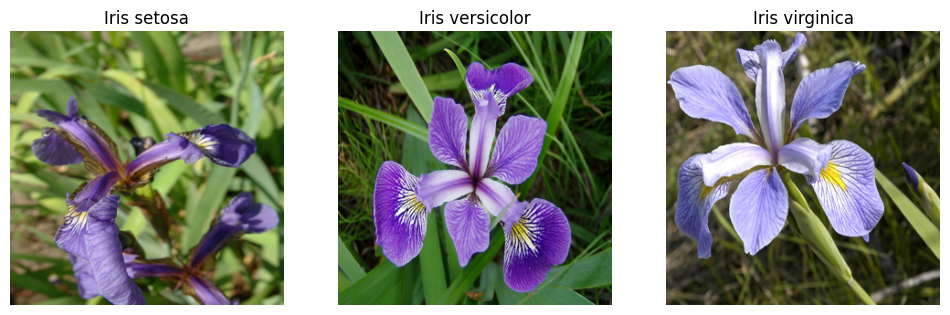

```python
plt.figure(figsize=(12,12));
plt.subplot(1,3,1), plt.imshow(image1.resize((300,300))), plt.axis("off"), plt.title("Iris setosa");
plt.subplot(1,3,2), plt.imshow(image2.resize((300,300))), plt.axis("off"), plt.title("Iris versicolor");
plt.subplot(1,3,3), plt.imshow(image3.resize((300,300))), plt.axis("off"), plt.title("Iris virginica");
plt.show()
```

## 2. Chuẩn bị vấn đề (Prepare Problem)

### 2.1. Khai báo thư viện (Load Libraries)

```python
# Load libraries
import os, sys
from IPython import display
import numpy as np
import matplotlib.pyplot as plt
import pandas as pd
import seaborn as sns
import joblib

from sklearn.preprocessing import OneHotEncoder, LabelEncoder, OrdinalEncoder
from sklearn.preprocessing import MinMaxScaler, StandardScaler
from sklearn.model_selection import train_test_split

import warnings

%matplotlib inline
# plt.rcParams["figure.figsize"] = (12, 6)
# plt.rcParams['figure.dpi'] = 100

warnings.filterwarnings("ignore")
```

### 2.2. Nạp dữ liệu (Load Dataset)

```python
# Load dataset
data_path  = f"../data/iris.csv"
data_names = ["sepal-length", "sepal-width", "petal-length", "petal-width", "class"]
df_dataset = pd.read_csv(data_path, names = data_names)
```

## 3. Phân tích khám phá dữ liệu (Exploration Analyze Data - EDA)

### 3.1. Thống kê mô tả (Descriptive Statistics) - Ungraphic Approach

#### (1) **Hiển thị một số thông tin về dữ liệu**

- Số dòng, số cột của dữ liệu
- Kiểu dữ liệu của từng cột
- 5 dòng đầu và 5 dòng cuối của bảng dữ liệu
- Thông tin chung về dữ liệu

```python
# shape
print(f'+ Shape: {df_dataset.shape}')
# types
print(f'+ Data Types: \n{df_dataset.dtypes}')
# head, tail
print(f'+ Contents: ')
display.display(df_dataset.head(5))
display.display(df_dataset.tail(5))
# info
df_dataset.info()
```

```
+ Shape: (150, 5)
+ Data Types:
sepal-length    float64
sepal-width     float64
petal-length    float64
petal-width     float64
class            object
dtype: object
+ Contents:
```

|  | sepal-length | sepal-width | petal-length | petal-width | class |
| --- | --- | --- | --- | --- | --- |
| 0 | 5.1 | 3.5 | 1.4 | 0.2 | Iris-setosa |
| 1 | 4.9 | 3.0 | 1.4 | 0.2 | Iris-setosa |
| 2 | 4.7 | 3.2 | 1.3 | 0.2 | Iris-setosa |
| 3 | 4.6 | 3.1 | 1.5 | 0.2 | Iris-setosa |
| 4 | 5.0 | 3.6 | 1.4 | 0.2 | Iris-setosa |

|  | sepal-length | sepal-width | petal-length | petal-width | class |
| --- | --- | --- | --- | --- | --- |
| 145 | 6.7 | 3.0 | 5.2 | 2.3 | Iris-virginica |
| 146 | 6.3 | 2.5 | 5.0 | 1.9 | Iris-virginica |
| 147 | 6.5 | 3.0 | 5.2 | 2.0 | Iris-virginica |
| 148 | 6.2 | 3.4 | 5.4 | 2.3 | Iris-virginica |
| 149 | 5.9 | 3.0 | 5.1 | 1.8 | Iris-virginica |

```
<class 'pandas.core.frame.DataFrame'>
RangeIndex: 150 entries, 0 to 149
Data columns (total 5 columns):
 #   Column        Non-Null Count  Dtype
---  ------        --------------  -----
 0   sepal-length  150 non-null    float64
 1   sepal-width   150 non-null    float64
 2   petal-length  150 non-null    float64
 3   petal-width   150 non-null    float64
 4   class         150 non-null    object
dtypes: float64(4), object(1)
memory usage: 6.0+ KB
```

**Nhận xét**:

- Dữ liệu có 4 tính chất để phân lớp: sepal-length, sepal-width, petal-length, petal-width
- Giá trị 4 tính chất được tính cùng đơn vị đo (cm)
- Tổng số dòng dữ liệu là 150 dòng
- Dữ liệu để phân lớp ở cột class

#### (2) **Kiểm tra tính toàn vẹn của dữ liệu**

- Dữ liệu có bị trùng lặp không? Hiển thị dòng bị vi phạm.
- Dữ liệu có tồn tại giá trị Null không? Hiển thị dòng bị vi phạm.
- Dữ liệu có tồn tại giá trị NaN không? Hiển thị dòng bị vi phạm.

```python
print("="*5, "Checking Null", "="*5)
display.display(df_dataset.isnull().sum())
has_null = df_dataset.isnull().sum().any()
print(f'--> Có giá trị Null: {has_null}')
if has_null:
    display.display(df_dataset[df_dataset.isnull().any(axis=1)])
```

```
===== Checking Null =====
```

```
sepal-length    0
sepal-width     0
petal-length    0
petal-width     0
class           0
dtype: int64
```

```
--> Có giá trị Null: False
```

```python
print("="*5, "Checking NaN", "="*5)
display.display(df_dataset.isna().sum())
has_nan  = df_dataset.isna().sum().any()
print(f'+ Có giá trị Nan: {has_nan}')
if has_nan:
    display.display(df_dataset[df_dataset.isna().any(axis=1)])
```

```
===== Checking NaN =====
```

```
sepal-length    0
sepal-width     0
petal-length    0
petal-width     0
class           0
dtype: int64
```

```
+ Có giá trị Nan: False
```

```python
print("="*5, "Checking Duplicated", "="*5)
n_duplicated = df_dataset.duplicated(keep = False).sum()
print(f'+ Số dòng trùng: {n_duplicated}')
display.display(df_dataset[df_dataset.duplicated(keep = False)])
if n_duplicated>0:
    print("+ Số dòng loại bỏ: %d"%(len(df_dataset[df_dataset.duplicated(keep = "first")])))
    display.display(df_dataset[df_dataset.duplicated(keep = "first")])
```

```
===== Checking Duplicated =====
+ Số dòng trùng: 5
```

|  | sepal-length | sepal-width | petal-length | petal-width | class |
| --- | --- | --- | --- | --- | --- |
| 9 | 4.9 | 3.1 | 1.5 | 0.1 | Iris-setosa |
| 34 | 4.9 | 3.1 | 1.5 | 0.1 | Iris-setosa |
| 37 | 4.9 | 3.1 | 1.5 | 0.1 | Iris-setosa |
| 101 | 5.8 | 2.7 | 5.1 | 1.9 | Iris-virginica |
| 142 | 5.8 | 2.7 | 5.1 | 1.9 | Iris-virginica |

```
+ Số dòng loại bỏ: 3
```

|  | sepal-length | sepal-width | petal-length | petal-width | class |
| --- | --- | --- | --- | --- | --- |
| 34 | 4.9 | 3.1 | 1.5 | 0.1 | Iris-setosa |
| 37 | 4.9 | 3.1 | 1.5 | 0.1 | Iris-setosa |
| 142 | 5.8 | 2.7 | 5.1 | 1.9 | Iris-virginica |

**Nhận xét**:

- Dữ liệu có 3 dòng bị trùng là dòng ở vị trí 34, 37, 142
- Dữ liệu không có giá trị rỗng (NaN, Null)

#### (3) **Các tính chất thống kê trên dữ liệu số**

- Count, Mean, Standard Deviation, Minimum Value
- 25th Percentile, 50th Percentile (Median), 75th Percentile, Maximum Value

```python
description = df_dataset.describe().T
display.display(description)
```

|  | count | mean | std | min | 25% | 50% | 75% | max |
| --- | --- | --- | --- | --- | --- | --- | --- | --- |
| sepal-length | 150.0 | 5.843333 | 0.828066 | 4.3 | 5.1 | 5.80 | 6.4 | 7.9 |
| sepal-width | 150.0 | 3.054000 | 0.433594 | 2.0 | 2.8 | 3.00 | 3.3 | 4.4 |
| petal-length | 150.0 | 3.758667 | 1.764420 | 1.0 | 1.6 | 4.35 | 5.1 | 6.9 |
| petal-width | 150.0 | 1.198667 | 0.763161 | 0.1 | 0.3 | 1.30 | 1.8 | 2.5 |

**Nhận xét**:

- 4 tính chất có cùng đơn vị đo (cm) nằm trong khoảng [0, 8]

#### (4) **Tần số xuất hiện (Distribution) trên dữ liệu phân lớp (Class) và dữ liệu danh mục (Category)**

Đối với bài toán phân lớp (classification problem), chúng ta cần tính số lần xuất hiện của thuộc tính phân lớp. Điều này là cần thiết cho vấn đề mất cân bằng (highly imbalanced problems) giữa các lớp nhằm cần xử lý đặc biệt trong bước chuẩn bị dữ liệu.

```python
df_dataset["class"].value_counts()
```

```
Iris-setosa        50
Iris-versicolor    50
Iris-virginica     50
Name: class, dtype: int64
```

**Nhận xét**:

- Dữ liệu cần phân loại 3 loài hoa Iris là Iris-virginica, Iris-setosa, và Iris-versicolor
- Các lớp là cân bằng nhau và có số lượng 50

#### (5) **Mối tương quan giữa các tính chất (Correlations)**

Sự tương quan (correlation) đề cập đến mối quan hệ giữa hai biến và cách chúng có thể có hoặc không cùng nhau thay đổi.

Phương pháp phổ biến nhất để tính toán tương quan là Pearson's Correlation Coeficient, giả định có một phân phối chuẩn của các thuộc tính liên quan. Tương quan -1 hoặc 1 cho thấy mối tương quan âm hoặc dương đầy đủ tương ứng. Trong khi giá trị 0 hiển thị không tương quan ở tất cả.

$$ r = \frac{\sum_{i=1}^n{\left(x_i - \hat{x}\right)\left(y_i - \hat{y}\right)}}{\sqrt{\sum_{i=1}^n{\left(x_i - \hat{x}\right)^2}\sum_{i=1}^n{\left(y_i - \hat{y}\right)^2}}} $$

Một số thuật toán học máy như hồi quy tuyến tính và logistic có hiệu suất kém nếu có các thuộc tính tương quan cao trong tập dữ liệu của bạn.

Như vậy, thật sự cần thiết để xem xét tất cả các mối tương quan theo cặp của các thuộc tính trong tập dữ liệu.

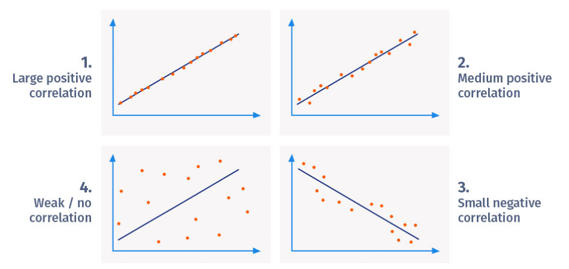

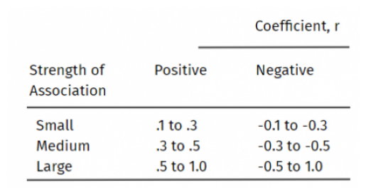

```python
plt.figure(figsize=(12, 6));
plt.imshow(plt.imread("corr1.png")), plt.axis("off"), plt.show();
plt.imshow(plt.imread("corr2.png")), plt.axis("off"), plt.show();
```

```python
correlations = df_dataset.corr(method='pearson')
display.display(correlations)
```

|  | sepal-length | sepal-width | petal-length | petal-width |
| --- | --- | --- | --- | --- |
| sepal-length | 1.000000 | -0.109369 | 0.871754 | 0.817954 |
| sepal-width | -0.109369 | 1.000000 | -0.420516 | -0.356544 |
| petal-length | 0.871754 | -0.420516 | 1.000000 | 0.962757 |
| petal-width | 0.817954 | -0.356544 | 0.962757 | 1.000000 |

**Nhận xét**:

- Các cặp tính chất có độ tương đồng cao:
  - (sepal-length, petal-length) = 0.872
  - (sepal-length, petal-width) = 0.818
  - (petal-length, petal-width) = 0.963

### 3.2. Hiển thị dữ liệu (Visualize Data) - Graphic Approach

#### (1) Hiển thị trên từng tính chất đơn (Univariate Plots)

##### Species (Class Label)

```
Iris-setosa        50
Iris-versicolor    50
Iris-virginica     50
Name: class, dtype: int64
```

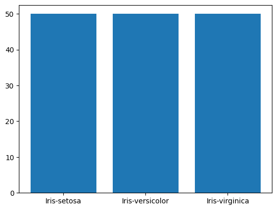

```python
# bar chart
counts = df_dataset["class"].value_counts()
plt.bar(counts.index, counts.values)
print(counts)
```

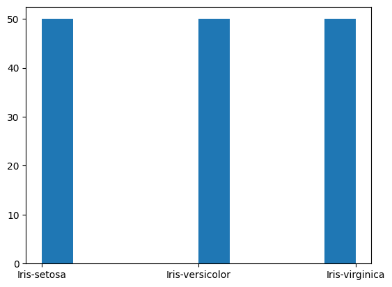

```python
# one way using histogram :)
plt.hist(df_dataset['class'])
```

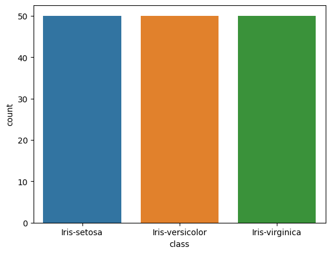

```python
# seaborn
sns.countplot(x = df_dataset['class']);
```

Notices:

- Classes are balanced
- It is safe to use different classification accuracy metrics
- No pre-processing setps are required to address data imbalance (augmentation, oversampling, downsampling)

##### Box and whisker plots

- https://www.simplypsychology.org/boxplots.html
- So sánh các trung vị (median) tương ứng của mỗi ô hộp (box plot). Nếu đường trung vị của một ô hộp nằm bên ngoài ô của một ô hộp so sánh, thì có thể có sự khác biệt giữa hai nhóm.
- So sánh chiều dài hộp để kiểm tra cách dữ liệu được phân tán giữa mỗi mẫu. Hộp càng dài thì dữ liệu càng phân tán. Dữ liệu càng nhỏ càng ít bị phân tán.
- Một ngoại lệ (outlier) được định nghĩa là một điểm dữ liệu nằm bên ngoài phần rìa (whiskers) của ô hộp.
- Kiểm tra hướng lệch của dữ liệu (cân đối, các phần tử tập trung trái, phải).
  - Median ở giữa hộp và râu (whiskers) ở hai bên như nhau thì phân bố là đối xứng.
  - Median ở gần đáy hộp hơn và nếu râu ngắn hơn ở đầu dưới của hộp, thì phân phối là lệch dương (lệch phải).
  - Median ở gần đầu hộp hơn và nếu râu ngắn hơn ở đầu trên của hộp, thì phân bố bị lệch âm (lệch trái).

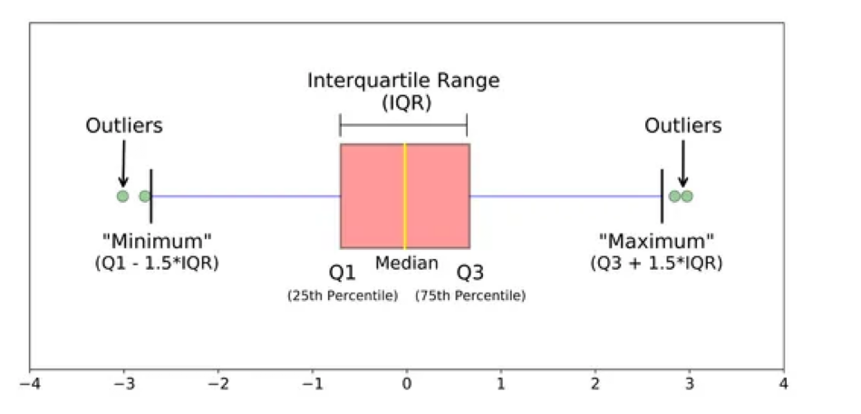

```python
plt.figure(figsize=(12, 6)), plt.imshow(plt.imread("boxplots.png")), plt.axis("off"), plt.show();
```

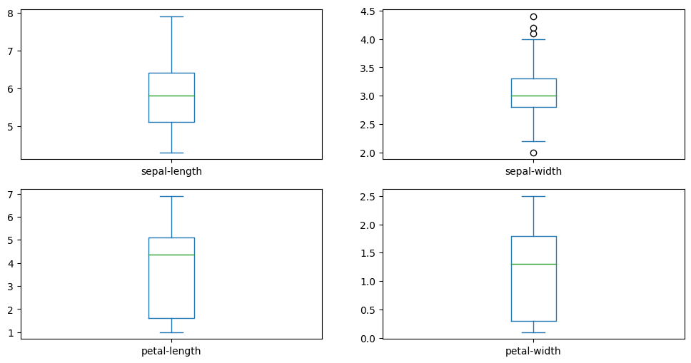

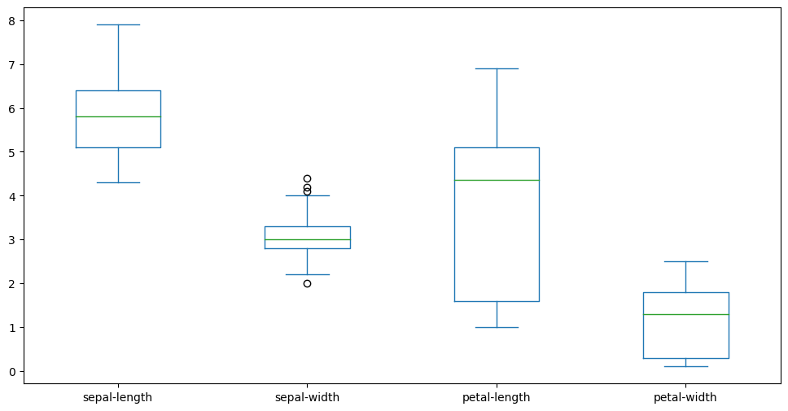

```python
df_dataset.plot(kind="box", subplots=True, layout=(2, 2), sharex=False, sharey=False, figsize=(12,6));
df_dataset.plot(kind="box", figsize=(12,6));
```

**Nhận xét**:

- Độ trải rộng giữa các tính chất khá khác nhau (sepal-width, sepal-length, petal-width, petal-length)
- Độ lệch của sepal-length, petal-length, petal-width theo hướng giá trị nhỏ.
- Phân bố giá trị của sepal-width khá cân bằng

##### Biểu đồ Histogram

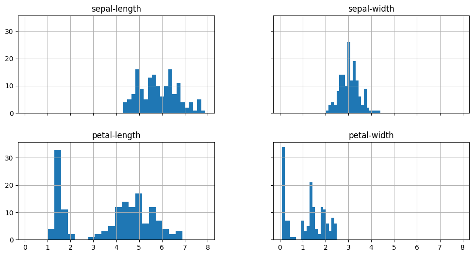

```python
df_dataset.hist(figsize=(12, 6), bins = 20, sharex = True, sharey = True);
```

##### Density Plots

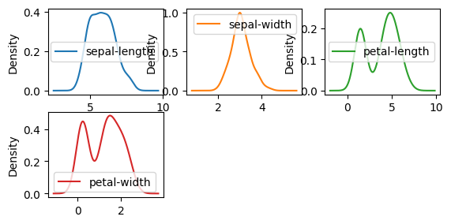

```python
df_dataset.plot(kind='density', subplots=True, layout=(3,3), sharex=False);
plt.show()
```

#### (2) Hiển thị nhiều tính chất (Multivariate Plots) using comparison graphs

##### Scatterplots

What?

- use a Cartesian coordinates system to display values of typically two variables for a set of data

Why?

- show the relationship between two variables

Let's try an example: Showing the scatterplot between the features 'sepal_length' and 'sepal_width'

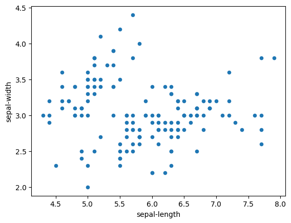

```python
# pandas
df_dataset.plot.scatter('sepal-length','sepal-width');
```

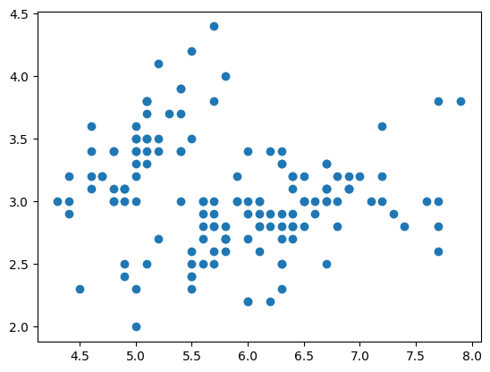

```python
# matplotlib
plt.scatter('sepal-length', 'sepal-width', data=df_dataset);
```

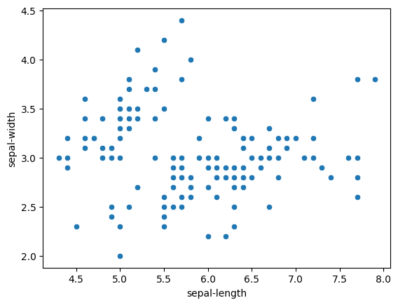

```python
# seaborn
sns.scatterplot(x = df_dataset['sepal-length'], y = df_dataset['sepal-width']);
# or sns.scatter('sepal-length', 'sepal-width', data=df_dataset);
```

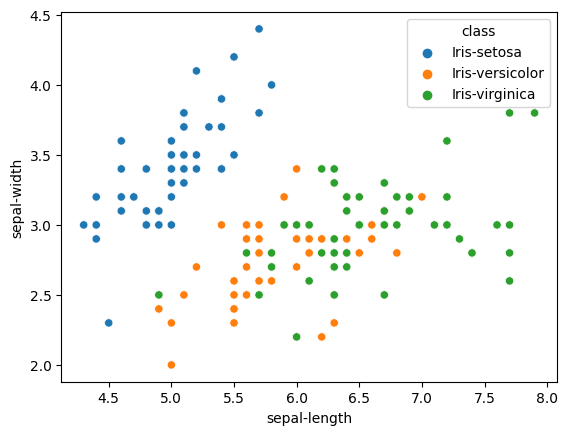

```python
# With respect to the target class (species)
sns.scatterplot(x = 'sepal-length', y = 'sepal-width', hue=df_dataset['class'], data=df_dataset)
```

** As seen above, different tools could be used, from now on only seaborn is shown and others are lift for you to search how to do it

##### Correlogram

Correlogram: AKS correlation matrix, to analyse the relationship between each pair of numeric variables

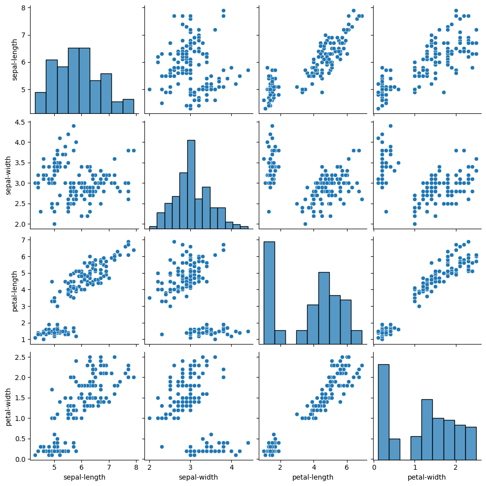

```python
# seaborn
sns.pairplot(df_dataset)
```

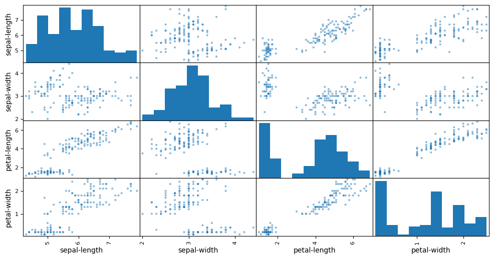

```python
# pandas
pd.plotting.scatter_matrix(df_dataset, figsize=(12,6));
```

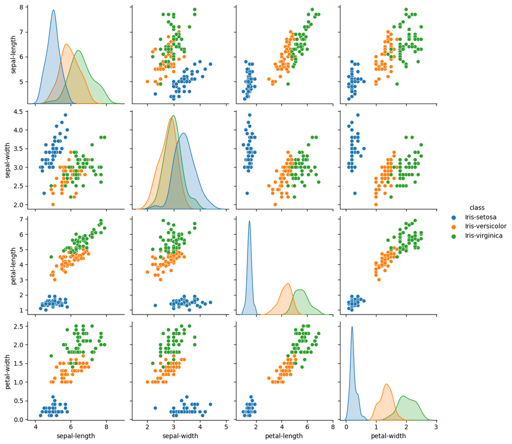

```python
# pairplot with class
sns.pairplot(df_dataset, hue="class")
```

##### Heatmap

Further, we can visualise this correlation using a heatmap.

Heatmap: a two-dimensional graphical representation of data where the individual values that are contained in a matrix are represented as colors

useful to see which intersections of the categorical values, have higher concentration of the data compared to the others

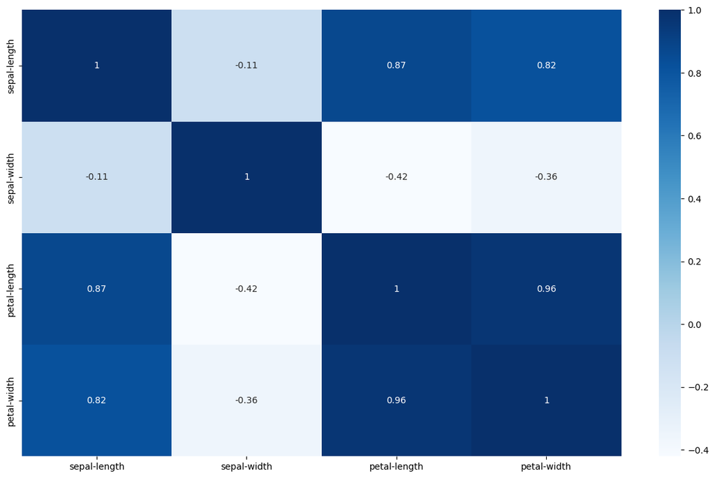

```python
fig = plt.figure(figsize = (15,9))
sns.heatmap(df_dataset.corr(), cmap='Blues', annot = True);
```

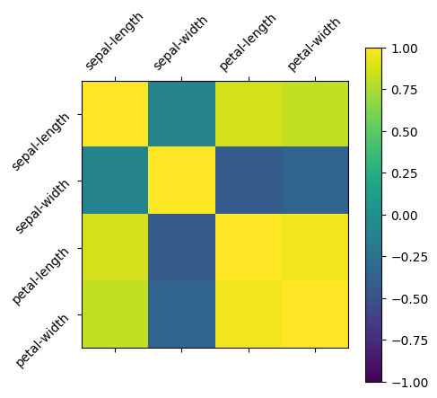

```python
# matplotlib
plt.matshow(correlations,vmin = -1, vmax = 1), plt.colorbar()
plt.xticks(np.arange(0,4), rotation = 45);
plt.yticks(np.arange(0,4), rotation = 45);
plt.gca().set_xticklabels(list(df_dataset.columns[:-1]));
plt.gca().set_yticklabels(list(df_dataset.columns[:-1]));
```

From the above heatmap, we see that petal_length and petal_width have a high correlation, petal_width and sepal_length have good correlation as well as petal_length and sepal_length have good correlations.

Các cặp tính chất có độ tương đồng cao:

- (sepal-length, petal-length) = 0.872
- (sepal-length, petal-width) = 0.818
- (petal-length, petal-width) = 0.963

##### Histograms and distributions

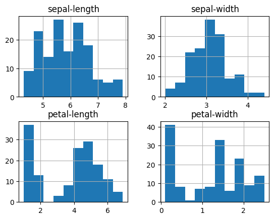

```python
df_dataset.hist();
```

##### Correlation with classification label

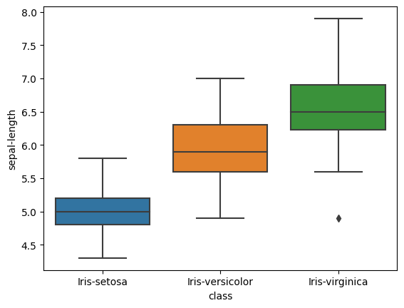

```python
# seaborn
sns.boxplot(x='class', y='sepal-length', data=df_dataset)
```

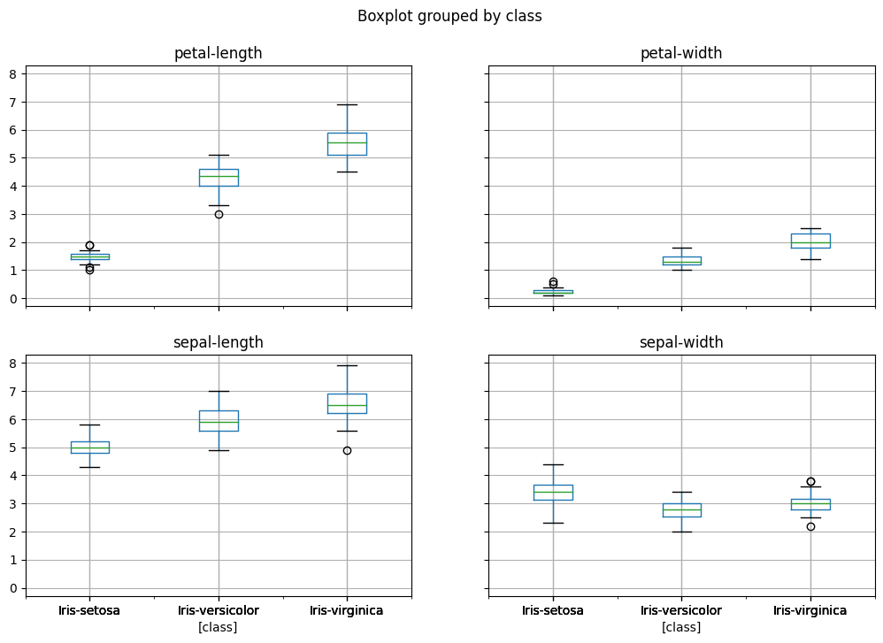

```python
df_dataset.boxplot(by="class", figsize=(12, 8));
```

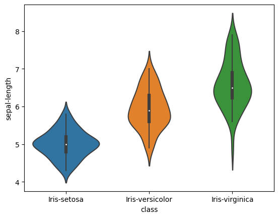

```python
sns.violinplot(x='class', y='sepal-length', data=df_dataset)
```

# Kết thúc

```python
!rm $cur_dir/eda.html
!jupyter nbconvert $cur_dir/eda.ipynb --to html
```

```
[NbConvertApp] Converting notebook /content/drive/MyDrive/ws/prj/adv_ds_2310/Lab05_Models/ex01_iris_classification/eda/eda.ipynb to html
[NbConvertApp] Writing 2889602 bytes to /content/drive/MyDrive/ws/prj/adv_ds_2310/Lab05_Models/ex01_iris_classification/eda/eda.html
```